# Data Exploration

```r
library("dplyr")
library("magrittr")
library("ggplot2")
library("fiftystater")
```

## 1. Feel of the data

We will first get a feel for our data set by getting a summary of the dataframe `churn_df`.

```r
churn_df <- read.csv("data/churn_train.csv", na.strings = c("", "NA"))
summary(churn_df)
```

```
     state      account_length            area_code    international_plan voice_mail_plan number_vmail_messages
 WV     : 106   Min.   :-209.00   area_code_408: 838   no :3010           no :2411        Min.   :-10.000
 MN     :  84   1st Qu.:  72.00   area_code_415:1655   yes: 323           yes: 922        1st Qu.:  0.000
 NY     :  83   Median : 100.00   area_code_510: 840                                      Median :  0.000
 AL     :  80   Mean   :  97.32                                                           Mean   :  7.333
 OH     :  78   3rd Qu.: 127.00                                                           3rd Qu.: 16.000
 OR     :  78   Max.   : 243.00                                                           Max.   : 51.000
 (Other):2824   NA's   :501                                                               NA's   :200
 total_day_minutes total_day_calls total_day_charge total_eve_minutes total_eve_calls total_eve_charge total_night_minutes
 Min.   :   0.0    Min.   :  0.0   Min.   : 0.00    Min.   :   0.0    Min.   :  0.0   Min.   : 0.00    Min.   : 23.2
 1st Qu.: 149.3    1st Qu.: 87.0   1st Qu.:24.45    1st Qu.: 170.5    1st Qu.: 87.0   1st Qu.:14.14    1st Qu.:167.3
 Median : 190.5    Median :101.0   Median :30.65    Median : 209.9    Median :100.0   Median :17.09    Median :201.4
 Mean   : 418.9    Mean   :100.3   Mean   :30.63    Mean   : 324.3    Mean   :100.1   Mean   :17.08    Mean   :201.2
 3rd Qu.: 237.8    3rd Qu.:114.0   3rd Qu.:36.84    3rd Qu.: 257.6    3rd Qu.:114.0   3rd Qu.:20.00    3rd Qu.:235.3
 Max.   :2185.1    Max.   :165.0   Max.   :59.64    Max.   :1244.2    Max.   :170.0   Max.   :30.91    Max.   :395.0
 NA's   :200       NA's   :200     NA's   :200      NA's   :301       NA's   :200     NA's   :200      NA's   :200
 total_night_calls total_night_charge total_intl_minutes total_intl_calls total_intl_charge number_customer_service_calls
 Min.   : 33.0     Min.   : 1.040     Min.   : 0.00      Min.   : 0.00    Min.   :0.000     Min.   :0.000
 1st Qu.: 87.0     1st Qu.: 7.530     1st Qu.: 8.50      1st Qu.: 3.00    1st Qu.:2.300     1st Qu.:1.000
 Median :100.0     Median : 9.060     Median :10.30      Median : 4.00    Median :2.780     Median :1.000
 Mean   :100.1     Mean   : 9.054     Mean   :10.23      Mean   : 4.47    Mean   :2.762     Mean   :1.561
 3rd Qu.:113.0     3rd Qu.:10.590     3rd Qu.:12.10      3rd Qu.: 6.00    3rd Qu.:3.270     3rd Qu.:2.000
 Max.   :175.0     Max.   :17.770     Max.   :20.00      Max.   :20.00    Max.   :5.400     Max.   :9.000
                   NA's   :200        NA's   :200        NA's   :301      NA's   :200       NA's   :200
 churn
 no :2850
 yes: 483
```

From the summary we can see that a lot of `NA` values are present in many columns execpt for the columns (variables) `state`, `area_code`, `international_plan`, `voice_mail_plan`, `total_night_calls`, and `churn`.

Out of the 6 variables that don’t have any `NA`s in them 5 are factors named ‘state’, ‘area_code’, ‘international_plan’, ‘voice_mail_plan’, ‘churn’. Five is also the total number of factors that can be observed in our data set, the rest are numerical variables.

If we take a closer look at the factor variables, the variable `state` seems to represent states from the USA (51 states in total). Below is a frequency table and a histogram showing us where most of the customers observed in the churn dataset come from in the US.

```r
state_freq <- churn_df %>%
  select(state) %>%
  group_by(state) %>%
  summarise(freq  = n()) %>%
  arrange(desc(freq))
state_freq
```

| state | freq |
| --- | --- |
| WV | 106 |
| MN | 84 |
| NY | 83 |
| AL | 80 |
| OH | 78 |
| OR | 78 |
| WI | 78 |
| VA | 77 |
| WY | 77 |
| CT | 74 |

[output cut: 41 more lines]

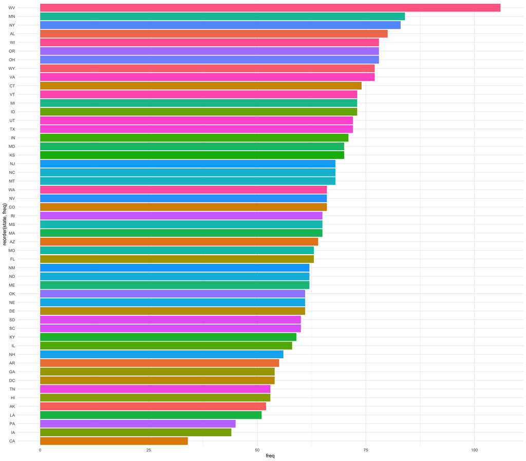

```r
ggplot(state_freq, aes(x = reorder(state, freq), y = freq, fill = state)) +
  geom_bar(stat = 'identity') +
  coord_flip() +
  theme_minimal() +
  guides(fill = F)
```

From the table and the histogram above we can see that **West Virginia** represents most the customers with a total of **106** customers. However, let’s see a visual representation of the density of customers on a map.

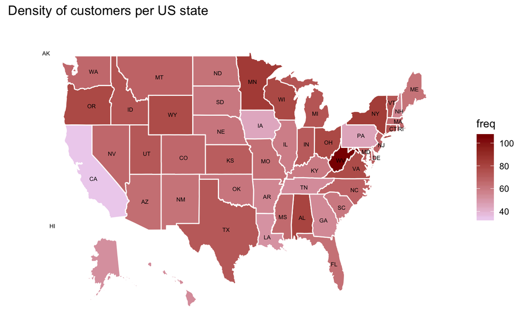

```r
ggplot(us_map_data, aes(x = long, y = lat)) +
  geom_map(
    map = us_map_data,
    color="#ffffff",
    aes(map_id = id)
  ) +
  geom_map(
    data = state_freq,
    map = us_map_data,
     color="#ffffff",
    aes(fill = freq, map_id = id)
  ) +
  scale_fill_continuous(low = 'thistle2', high = 'darkred', guide='colorbar') +
  geom_text(
    data = state_ctrs,
    size = 2,
    aes(x = c_long, y = c_lat, label = state)
  ) +
  coord_cartesian(xlim = c(-130, -65), ylim = c(24, 51)) +
  theme(
    axis.ticks = element_blank(),
    axis.text = element_blank(),
    panel.background = element_blank(),
    panel.border = element_blank()
  ) +
  labs(x = NULL, y = NULL, title = "Density of customers per US state")
```

## 2. What’s Up With The Negatives

From the output of the summary we noticed that some variables had negative values present in them, let’s take a look at those variables:

```r
churn_df %>%
  select(account_length, number_vmail_messages) %>%
  summary()
```

```
 account_length    number_vmail_messages
 Min.   :-209.00   Min.   :-10.000
 1st Qu.:  72.00   1st Qu.:  0.000
 Median : 100.00   Median :  0.000
 Mean   :  97.32   Mean   :  7.333
 3rd Qu.: 127.00   3rd Qu.: 16.000
 Max.   : 243.00   Max.   : 51.000
 NA's   :501       NA's   :200
```

`account_length` has values ranging from -209 and 243. The variable `account_length` is not immediatley obvious what it represents but in the domain of this data set, `account_length` represents how long a customer has had an account in terms of months (we are assuming `account_length` is in months). With that being said `account_length` should not contain any negative values.

`number_vmail_messages` has values ranging from -10 to 51, this variable represents the number of voice mail messages a customer has had, clearly such a variable should not have negative values in them.

## 3. NAs Everywhere

For a better understanding of the presence of `NA`s in our dataframe. Let’s look at the percentage of `NA`s accross all the variables in the dataframe.

```r
# A function to compute the percentage of NAs accross all columns.
na_percentage <- function(df, fmt = F) {
  return (df %>%
            is.na() %>%
            colMeans() %>%
            sapply(function(x) {
              if (fmt) {
                return(sprintf("%.5f%%", x * 100))
              }
              return (x)
            })
          )
}
na_percent_df <- na_percentage(churn_df) %>%
  data_frame(Columns = names(.), `NA %` = .) %>%
  mutate_at(
    vars(`NA %`),
    funs(round(. * 100, 2))
  ) %>%
  mutate(label = sprintf("%g%%", `NA %`)) %>%
  arrange(desc(`NA %`))
na_percent_df %>% select(-label)
```

| Columns | NA % |
| --- | --- |
| account_length | 15.03 |
| total_eve_minutes | 9.03 |
| total_intl_calls | 9.03 |
| number_vmail_messages | 6.00 |
| total_day_minutes | 6.00 |
| total_day_calls | 6.00 |
| total_day_charge | 6.00 |
| total_eve_calls | 6.00 |
| total_eve_charge | 6.00 |
| total_night_minutes | 6.00 |

[output cut: 10 more lines]

The table above lists all the variables (columns) and their respective percentage of `NA`s. We can see that most categorical variables such as `state`, `area_code`, `international_plan`, etc. including `total_night_calls` (numerical variable) have no `NA` values in them.

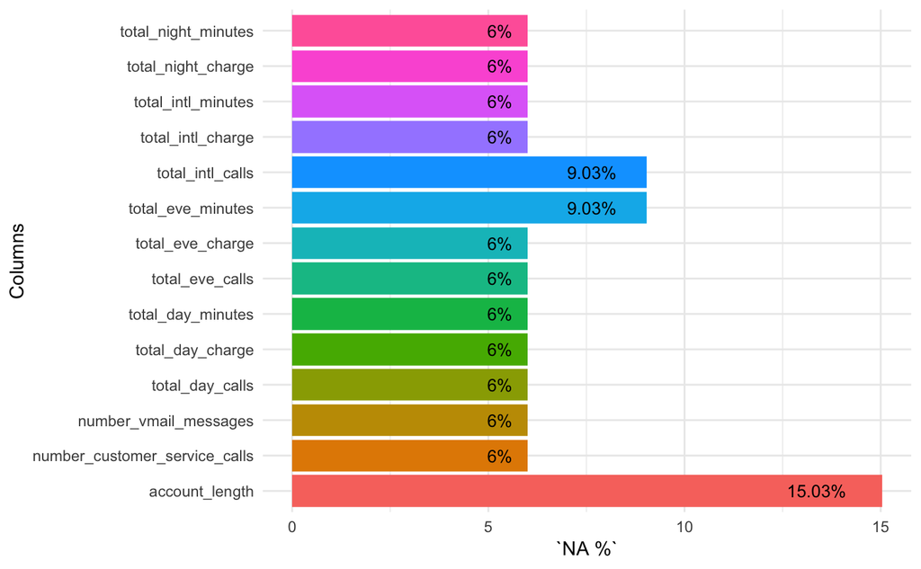

```r
na_percent_df %>%
  filter(`NA %`> 0) %>%
  ggplot(aes(x = Columns, y = `NA %`, fill = Columns)) +
  geom_bar(stat="identity") +
  guides(fill = F) +
  coord_flip() +
  geom_text(aes(label = label), hjust = 1.6, size = 3.5) +
  theme_minimal()
```

Further analysis of the `NA` percentage table, we noticed that 11 variables have an `NA` percentage of **6%**. Such a pattern is interesting and deserves a closer look.

Below is a table that shows only the variables that have `NA` in them. The code chunk removes columns that have an `NA` percentage of **0%** and then only shows rows that have at least 1 `NA` value in them.

```r
na_df <- churn_df %>%
  select(-state, -area_code, -international_plan, -voice_mail_plan, -total_night_calls, -churn) %>%
  filter_all(any_vars(is.na(.)))
na_df
```

| account_length | number_vmail_messages | total_day_minutes | total_day_calls | total_day_charge | total_eve_minutes | total_eve_calls | total_eve_charge | total_night_minutes | total_night_charge | total_intl_minutes | total_intl_calls | total_intl_charge | number_customer_service_calls |
| --- | --- | --- | --- | --- | --- | --- | --- | --- | --- | --- | --- | --- | --- |
| NA | 30 | 110.3 | 71 | 18.75 | 182.4 | 108 | 15.50 | 183.8 | 8.27 | 11.0 | 8 | 2.97 | 2 |
| 89 | 0 | 178.7 | 81 | 30.38 | NA | 74 | 19.86 | 131.9 | 5.94 | 9.1 | 4 | 2.46 | 1 |
| 65 | 0 | 129.1 | 137 | 21.95 | NA | 83 | 19.42 | 208.8 | 9.40 | 12.7 | 6 | 3.43 | 4 |
| NA | NA | NA | NA | NA | NA | NA | NA | NA | NA | NA | NA | NA | NA |
| NA | 32 | 247.0 | 109 | 41.99 | 125.6 | 91 | 10.68 | 226.5 | 10.19 | 10.5 | 4 | 2.84 | 3 |
| NA | 0 | 150.9 | 79 | 25.65 | 161.8 | 87 | 13.75 | 167.7 | 7.55 | 11.7 | 5 | 3.16 | 3 |
| 89 | 0 | 134.9 | 59 | 22.93 | NA | 152 | 13.26 | 197.5 | 8.89 | 10.2 | 5 | 2.75 | 1 |
| NA | NA | NA | NA | NA | NA | NA | NA | NA | NA | NA | NA | NA | NA |
| NA | NA | NA | NA | NA | NA | NA | NA | NA | NA | NA | NA | NA | NA |
| NA | 0 | 198.6 | 111 | 33.76 | 213.9 | 115 | 18.18 | 171.2 | 7.70 | 10.6 | 6 | 2.86 | 2 |

[output cut: 693 more lines]

We can see that there are many `NA` values present in this the 703 row subset of our data set. There are 503 rows that have at least **1** `NA` in one of their columns while 200 rows have all its elements consisting of completely `NA` values.

## 4. Preliminary Data Cleaning

### 4.1 Turning Negatives into Positives

In order to deal with those variables that have negative values in them, the simple strategy is to turn all the numbers for each variable in question to positive using the `abs` function.

```r
churn_df <- churn_df %>%
  mutate_at(.vars = vars(account_length, number_vmail_messages), .funs = funs(abs))
summary(churn_df)
```

```
     state      account_length          area_code    international_plan voice_mail_plan number_vmail_messages
 WV     : 106   Min.   :  1.0   area_code_408: 838   no :3010           no :2411        Min.   : 0.000
 MN     :  84   1st Qu.: 73.0   area_code_415:1655   yes: 323           yes: 922        1st Qu.: 0.000
 NY     :  83   Median :101.0   area_code_510: 840                                      Median : 0.000
 AL     :  80   Mean   :100.8                                                           Mean   : 8.056
 OH     :  78   3rd Qu.:127.0                                                           3rd Qu.:16.000
 OR     :  78   Max.   :243.0                                                           Max.   :51.000
 (Other):2824   NA's   :501                                                             NA's   :200
 total_day_minutes total_day_calls total_day_charge total_eve_minutes total_eve_calls total_eve_charge total_night_minutes
 Min.   :   0.0    Min.   :  0.0   Min.   : 0.00    Min.   :   0.0    Min.   :  0.0   Min.   : 0.00    Min.   : 23.2
 1st Qu.: 149.3    1st Qu.: 87.0   1st Qu.:24.45    1st Qu.: 170.5    1st Qu.: 87.0   1st Qu.:14.14    1st Qu.:167.3
 Median : 190.5    Median :101.0   Median :30.65    Median : 209.9    Median :100.0   Median :17.09    Median :201.4
 Mean   : 418.9    Mean   :100.3   Mean   :30.63    Mean   : 324.3    Mean   :100.1   Mean   :17.08    Mean   :201.2
 3rd Qu.: 237.8    3rd Qu.:114.0   3rd Qu.:36.84    3rd Qu.: 257.6    3rd Qu.:114.0   3rd Qu.:20.00    3rd Qu.:235.3
 Max.   :2185.1    Max.   :165.0   Max.   :59.64    Max.   :1244.2    Max.   :170.0   Max.   :30.91    Max.   :395.0
 NA's   :200       NA's   :200     NA's   :200      NA's   :301       NA's   :200     NA's   :200      NA's   :200
 total_night_calls total_night_charge total_intl_minutes total_intl_calls total_intl_charge number_customer_service_calls
 Min.   : 33.0     Min.   : 1.040     Min.   : 0.00      Min.   : 0.00    Min.   :0.000     Min.   :0.000
 1st Qu.: 87.0     1st Qu.: 7.530     1st Qu.: 8.50      1st Qu.: 3.00    1st Qu.:2.300     1st Qu.:1.000
 Median :100.0     Median : 9.060     Median :10.30      Median : 4.00    Median :2.780     Median :1.000
 Mean   :100.1     Mean   : 9.054     Mean   :10.23      Mean   : 4.47    Mean   :2.762     Mean   :1.561
 3rd Qu.:113.0     3rd Qu.:10.590     3rd Qu.:12.10      3rd Qu.: 6.00    3rd Qu.:3.270     3rd Qu.:2.000
 Max.   :175.0     Max.   :17.770     Max.   :20.00      Max.   :20.00    Max.   :5.400     Max.   :9.000
                   NA's   :200        NA's   :200        NA's   :301      NA's   :200       NA's   :200
 churn
 no :2850
 yes: 483
```

From the summary table, we can see that all our variables are positive. `account_length` ranges from 1 to 243 and `number_vmail_messages` ranges from 0 to 51.

### 4.2 No More NAs

Rows in which we have discovered that are completely filled up with `NA` values pose a problem for us. The problem is that they don’t have enough data in them which we can use for predicting churn. Each row represents a customer and if a row has 14 elements (representing the 14 columns) consisting of `NA` then that customer is essentially incosiquential in the training of our model.

Imputing of missing values is an approach to solving this problem but in this particular case it would be pointless to do so for rows which have so much of its predictive power missing. There are some rows in which we can impute missing values in, these rows can be salvaged because the percentage of `NA`s in them is not 100%.

```r
churn_df_1 <- churn_df[rowMeans(is.na(churn_df)) <= 0.25,]
summary(churn_df_1)
```

```
     state      account_length          area_code    international_plan voice_mail_plan number_vmail_messages
 WV     : 100   Min.   :  1.0   area_code_408: 796   no :2832           no :2259        Min.   : 0.000
 AL     :  79   1st Qu.: 73.0   area_code_415:1563   yes: 301           yes: 874        1st Qu.: 0.000
 MN     :  78   Median :101.0   area_code_510: 774                                      Median : 0.000
 NY     :  77   Mean   :100.8                                                           Mean   : 8.056
 OH     :  76   3rd Qu.:127.0                                                           3rd Qu.:16.000
 OR     :  75   Max.   :243.0                                                           Max.   :51.000
 (Other):2648   NA's   :301
 total_day_minutes total_day_calls total_day_charge total_eve_minutes total_eve_calls total_eve_charge total_night_minutes
 Min.   :   0.0    Min.   :  0.0   Min.   : 0.00    Min.   :   0.0    Min.   :  0.0   Min.   : 0.00    Min.   : 23.2
 1st Qu.: 149.3    1st Qu.: 87.0   1st Qu.:24.45    1st Qu.: 170.5    1st Qu.: 87.0   1st Qu.:14.14    1st Qu.:167.3
 Median : 190.5    Median :101.0   Median :30.65    Median : 209.9    Median :100.0   Median :17.09    Median :201.4
 Mean   : 418.9    Mean   :100.3   Mean   :30.63    Mean   : 324.3    Mean   :100.1   Mean   :17.08    Mean   :201.2
 3rd Qu.: 237.8    3rd Qu.:114.0   3rd Qu.:36.84    3rd Qu.: 257.6    3rd Qu.:114.0   3rd Qu.:20.00    3rd Qu.:235.3
 Max.   :2185.1    Max.   :165.0   Max.   :59.64    Max.   :1244.2    Max.   :170.0   Max.   :30.91    Max.   :395.0
                                                    NA's   :101
 total_night_calls total_night_charge total_intl_minutes total_intl_calls total_intl_charge number_customer_service_calls
 Min.   : 33.0     Min.   : 1.040     Min.   : 0.00      Min.   : 0.00    Min.   :0.000     Min.   :0.000
 1st Qu.: 87.0     1st Qu.: 7.530     1st Qu.: 8.50      1st Qu.: 3.00    1st Qu.:2.300     1st Qu.:1.000
 Median :100.0     Median : 9.060     Median :10.30      Median : 4.00    Median :2.780     Median :1.000
 Mean   :100.1     Mean   : 9.054     Mean   :10.23      Mean   : 4.47    Mean   :2.762     Mean   :1.561
 3rd Qu.:114.0     3rd Qu.:10.590     3rd Qu.:12.10      3rd Qu.: 6.00    3rd Qu.:3.270     3rd Qu.:2.000
 Max.   :175.0     Max.   :17.770     Max.   :20.00      Max.   :20.00    Max.   :5.400     Max.   :9.000
                                                         NA's   :101
 churn
 no :2676
 yes: 457
```

```r
na_df_1 <- na_percentage(churn_df_1) %>%
  data_frame(Columns = names(.), `NA %` = .) %>%
  mutate_at(
    vars(`NA %`),
    funs(round(. * 100, 2))
  ) %>%
  mutate(label = sprintf("%g%%", `NA %`)) %>%
  arrange(desc(`NA %`))
na_df_1
```

| Columns | NA % | label |
| --- | --- | --- |
| account_length | 9.61 | 9.61% |
| total_eve_minutes | 3.22 | 3.22% |
| total_intl_calls | 3.22 | 3.22% |
| state | 0.00 | 0% |
| area_code | 0.00 | 0% |
| international_plan | 0.00 | 0% |
| voice_mail_plan | 0.00 | 0% |
| number_vmail_messages | 0.00 | 0% |
| total_day_minutes | 0.00 | 0% |
| total_day_calls | 0.00 | 0% |

[output cut: 10 more lines]

Let’s look at a visual presentation of how the `NA` values have changed.

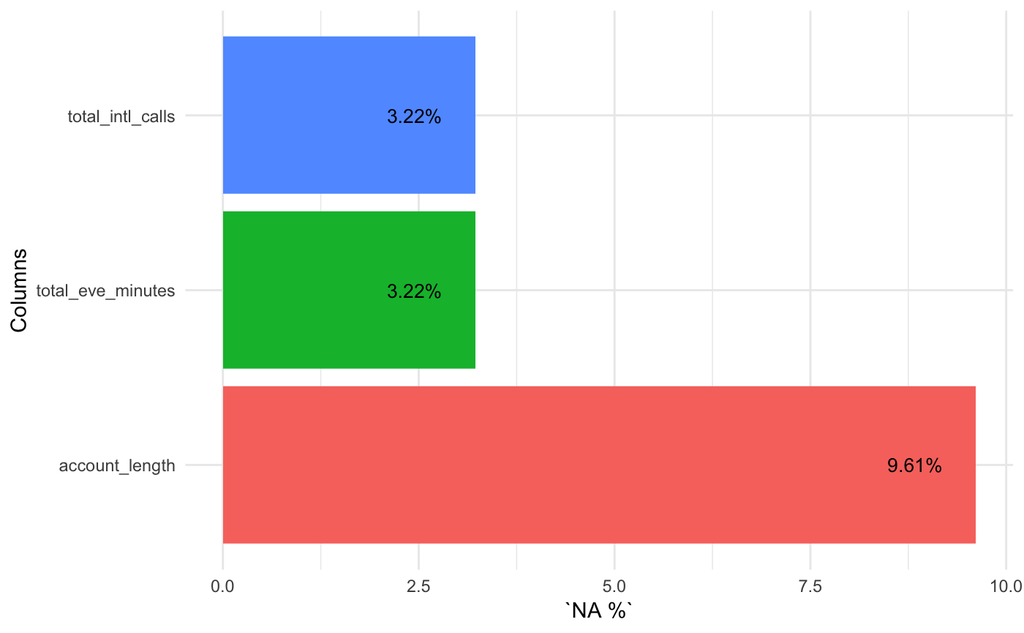

```r
na_df_1 %>%
  filter(`NA %`> 0) %>%
  ggplot(aes(x = Columns, y = `NA %`, fill = Columns)) +
  geom_bar(stat="identity") +
  guides(fill = F) +
  coord_flip() +
  geom_text(aes(label = label), hjust = 1.6, size = 3.5) +
  theme_minimal()
```

Let’s subset our dataset and look at the columns we initially identified has having at least 1 NA in them.

```r
churn_df_1 %>%
  select(-state, -area_code, -international_plan, -voice_mail_plan, -total_night_calls, -churn) %>%
  filter_all(any_vars(is.na(.)))
```

| account_length | number_vmail_messages | total_day_minutes | total_day_calls | total_day_charge | total_eve_minutes | total_eve_calls | total_eve_charge | total_night_minutes | total_night_charge | total_intl_minutes | total_intl_calls | total_intl_charge | number_customer_service_calls |
| --- | --- | --- | --- | --- | --- | --- | --- | --- | --- | --- | --- | --- | --- |
| NA | 30 | 110.3 | 71 | 18.75 | 182.4 | 108 | 15.50 | 183.8 | 8.27 | 11.0 | 8 | 2.97 | 2 |
| 89 | 0 | 178.7 | 81 | 30.38 | NA | 74 | 19.86 | 131.9 | 5.94 | 9.1 | 4 | 2.46 | 1 |
| 65 | 0 | 129.1 | 137 | 21.95 | NA | 83 | 19.42 | 208.8 | 9.40 | 12.7 | 6 | 3.43 | 4 |
| NA | 32 | 247.0 | 109 | 41.99 | 125.6 | 91 | 10.68 | 226.5 | 10.19 | 10.5 | 4 | 2.84 | 3 |
| NA | 0 | 150.9 | 79 | 25.65 | 161.8 | 87 | 13.75 | 167.7 | 7.55 | 11.7 | 5 | 3.16 | 3 |
| 89 | 0 | 134.9 | 59 | 22.93 | NA | 152 | 13.26 | 197.5 | 8.89 | 10.2 | 5 | 2.75 | 1 |
| NA | 0 | 198.6 | 111 | 33.76 | 213.9 | 115 | 18.18 | 171.2 | 7.70 | 10.6 | 6 | 2.86 | 2 |
| 107 | 22 | 281.1 | 83 | 47.79 | 143.7 | 130 | 12.21 | 239.4 | 10.77 | 11.2 | NA | 3.02 | 1 |
| NA | 0 | 220.8 | 111 | 37.54 | 156.2 | 67 | 13.28 | 187.9 | 8.46 | 10.5 | 4 | 2.84 | 2 |
| NA | 0 | 246.5 | 108 | 41.91 | 216.3 | 89 | 18.39 | 179.6 | 8.08 | 12.7 | 3 | 3.43 | 2 |

[output cut: 493 more lines]

Now that we have removed rows which had very little information in them, we can focus on figuring out a strategy on filling in the missing values of our remaining 503 rows.

### 4.3 The Remaining NAs

We have about 503 `NA` values in total in our dataset of which `account_length` owns 9.61% of it while `total_eve_minutes` and `total_intl_class` both own 3.22%.

Looking at `account_length` we were not convinced that it was statistically significant or that it had any predictive power when it came to predicting churn. In order to investigate our hypothesis, we compared the correlation of `churn` and `account_length` using a box plot as seen below. The aim is to see whether `account_length` can clearly differentiate between **no** and **yes**.

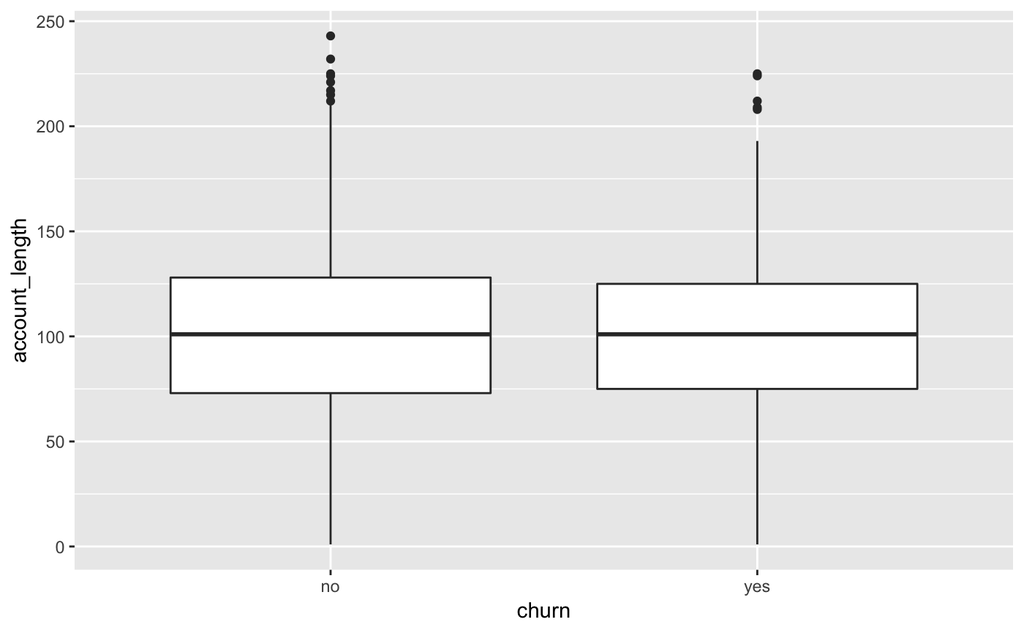

```r
ggplot(churn_df_1, aes(churn, account_length)) +
  geom_boxplot()
```

The boxplot tells us that `account_length` can not differentiate between **no** and **yes**. As `account_length` increases the number of **no** and **yes** varies very little meaning `account_length` is not a good predictor of `churn`.

Upon validating our hypothesis, we decided on moving forward with the descision to omit `account_length` from the dataset. The benefit of this is that we get rid of the **301** `NA` values in our dataset, which we would have had to spend time imputing for if we had kept `account_length`.

The descision of omitting `account_length` from our data set benefits us in that

1. It helps us avoid spending uneccesary effort in imputing a large percentage of missing values contributed by `account_length`
2. We remove a variable that has neither predictive power or is statistically significance.

## 5. Concluding The Exploration

We will omit `account_length` from our data set and then view the summary.

```r
churn_df_2 <- churn_df_1 %>% select(-account_length)
summary(churn_df_2)
```

```
     state              area_code    international_plan voice_mail_plan number_vmail_messages total_day_minutes
 WV     : 100   area_code_408: 796   no :2832           no :2259        Min.   : 0.000        Min.   :   0.0
 AL     :  79   area_code_415:1563   yes: 301           yes: 874        1st Qu.: 0.000        1st Qu.: 149.3
 MN     :  78   area_code_510: 774                                      Median : 0.000        Median : 190.5
 NY     :  77                                                           Mean   : 8.056        Mean   : 418.9
 OH     :  76                                                           3rd Qu.:16.000        3rd Qu.: 237.8
 OR     :  75                                                           Max.   :51.000        Max.   :2185.1
 (Other):2648
 total_day_calls total_day_charge total_eve_minutes total_eve_calls total_eve_charge total_night_minutes total_night_calls
 Min.   :  0.0   Min.   : 0.00    Min.   :   0.0    Min.   :  0.0   Min.   : 0.00    Min.   : 23.2       Min.   : 33.0
 1st Qu.: 87.0   1st Qu.:24.45    1st Qu.: 170.5    1st Qu.: 87.0   1st Qu.:14.14    1st Qu.:167.3       1st Qu.: 87.0
 Median :101.0   Median :30.65    Median : 209.9    Median :100.0   Median :17.09    Median :201.4       Median :100.0
 Mean   :100.3   Mean   :30.63    Mean   : 324.3    Mean   :100.1   Mean   :17.08    Mean   :201.2       Mean   :100.1
 3rd Qu.:114.0   3rd Qu.:36.84    3rd Qu.: 257.6    3rd Qu.:114.0   3rd Qu.:20.00    3rd Qu.:235.3       3rd Qu.:114.0
 Max.   :165.0   Max.   :59.64    Max.   :1244.2    Max.   :170.0   Max.   :30.91    Max.   :395.0       Max.   :175.0
                                  NA's   :101
 total_night_charge total_intl_minutes total_intl_calls total_intl_charge number_customer_service_calls churn
 Min.   : 1.040     Min.   : 0.00      Min.   : 0.00    Min.   :0.000     Min.   :0.000                 no :2676
 1st Qu.: 7.530     1st Qu.: 8.50      1st Qu.: 3.00    1st Qu.:2.300     1st Qu.:1.000                 yes: 457
 Median : 9.060     Median :10.30      Median : 4.00    Median :2.780     Median :1.000
 Mean   : 9.054     Mean   :10.23      Mean   : 4.47    Mean   :2.762     Mean   :1.561
 3rd Qu.:10.590     3rd Qu.:12.10      3rd Qu.: 6.00    3rd Qu.:3.270     3rd Qu.:2.000
 Max.   :17.770     Max.   :20.00      Max.   :20.00    Max.   :5.400     Max.   :9.000
                                       NA's   :101
```

Currently we have only **202** `NA` values essentially removing **301** `NA` values from `account_length`. We now need to impute values for **202** `NA`s

We will save the data frame, `churn_df_2`, that has gone through the preliminary data cleaning phase for data imputation.

```r
save(churn_df_2, file = "data/data_exploration.rda")
```